- ES218 Home
- [Moodle](https://moodle.colby.edu/course/view.php?id=8060)
- Data sets

# The theoretical q-q

This tutorial makes use of the following R package(s): **`ggplot2`**, **`dplyr`**, **`lattice`** (for data only).

This material is intended to supplement **section 2.4** of **Cleveland’s book**.

# Introduction

Thus far, we have used the quantile-quantile plots to compare the distributions between two empirical (i.e. observational) datasets. We can also use the q-q plot to compare an empirical observation to a theoretical observation (i.e. one defined mathematically). Examples of popular theoretical observations are the normal distribution (aka the Gaussian distribution), the chi-square distribution, and the exponential distribution just to name a few.

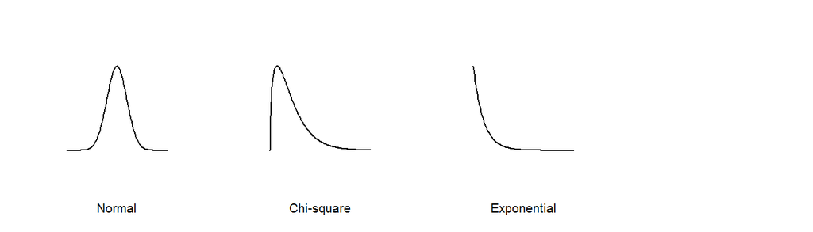

There are many reasons we might want to compare empirical data to theoretical distributions:

- A theoretical distribution is easy to parameterize. For example, if the shape of the distribution of a batch of numbers can be approximated by a normal distribution we can reduce the complexity of our data to just two values: the mean and the standard deviation.
- If data can be approximated by certain theoretical distributions, then many mainstream statistical procedures can be applied to the data.
- In inferential statistics, knowing that a sample was derived from a population whose distribution follows a theoretical distribution allows us to derive certain properties of the population from the sample. For example, if we know that a sample comes from a normally distributed population, we can define confidence intervals for the sample mean using a t-distribution.
- Modeling the distribution of the observed data can provide insight into the underlying process that generated the data.

But very few empirical datasets follow any theoretical distributions exactly. So the questions usually ends up being “how well does theoretical distribution *X* fit my data?”

The theoretical quantile-quantile plot is a tool to explore how a batch of numbers deviates from a theoretical distribution and to visually assess whether the difference is significant for the purpose of the analysis. In the following examples, we will compare empirical data to the normal distribution using the **normal quantile-quantile** plot.

# The normal q-q plot

The *normal q-q plot* is just a special case of the *empirical q-q plot* we’ve explored so far; the difference being that we assign the normal distribution quantiles to the x-axis.

## Drawing a normal q-q plot from scratch

In the following example, we’ll compare the `Alto 1` group to a normal distribution. First, we’ll extract the `Alto 1` height values and save them as an atomic vector object using `dplyr`’s piping operations. However, `dplyr`’s operations will return a dataframe–even if a single column is select. To force the output to an atomic vector, we’ll pipe the subset to `.$height` which will extract the `height` column into a plain vector element.

```r
library(dplyr)

df   <- lattice::singer
alto <- df %>%  filter(voice.part == "Alto 1") %>% .$height
```

Next, we need to sort `alto` in ascending order.

```r
alto <- sort(alto)
```

Next, we need to find the matching normal distribution quantiles. We first find the quantiles for `alto`, then use `qnorm` to find the matching normal distribution values from the quantiles.

```r
i      <- 1:length(alto)
fi     <- (i - 0.5) / length(alto)
x.norm <- qnorm(fi)
```

Now we can plot the sorted `alto` values against the normal values.

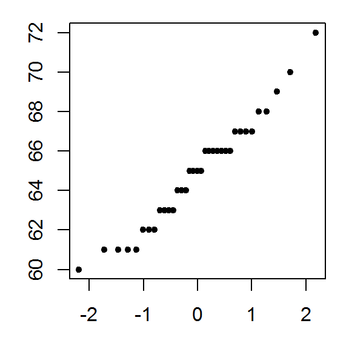

```r
plot( alto ~ x.norm, type="p", xlab="Normal quantiles", pch=20)
```

When comparing a batch of numbers to a theoretical distribution on a q-q plot, we are looking for significant deviation from a straight line. To make it easier to judge straightness, we can fit a line to the points. Note that we are **not** creating a 45° (or x=y) slope; the range of values between both sets of numbers do not match. Here, we are only seeking the **straightness** of the points.

There are many ways one can fit a line to the data, Cleveland opts to fit a line to the first and third quartile of the q-q plot. The following chunk of code identifies the quantiles for both the `alto` dataset and the theoretical normal distribution. It then computes the slope and intercept for that line.

```r
# Find 1st and 3rd quartile for the Alto 1 data
y <- quantile(alto, c(0.25, 0.75))

# Find the 1st and 3rd quartile of the normal distribution
x <- qnorm( c(0.25, 0.75))

# Now we can compute the intercept and slope of the line that passes
# through these points
slope <- diff(y) / diff(x)
int   <- y[1] - slope * x[1]
```

Next, we add the line to the plot.

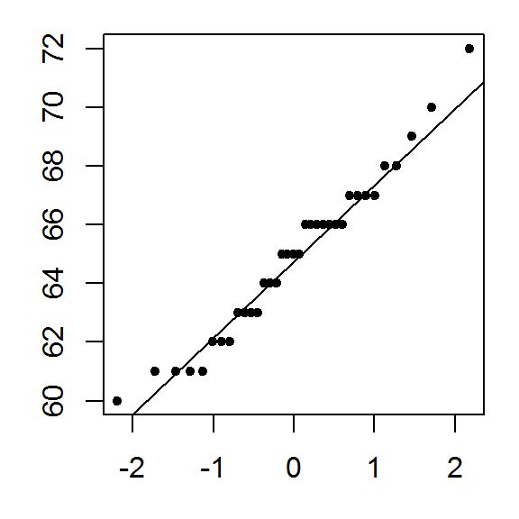

```r
abline(a=int, b=slope )
```

## Using R’s built-in functions

R has two built-in functions that facilitate the plot building task when comparing a batch to a normal distribution: `qqnorm` and `qqline`.

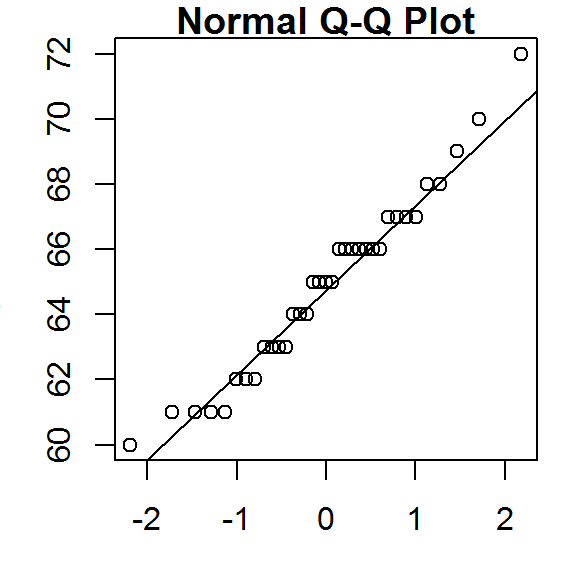

```r
qqnorm(alto)
qqline(alto)
```

That’s it. Just two lines of code!

## Using the ggplot2 plotting environment

We can take advantage of the `stat_qq()` function to plot the points, but the equation for the line must be computed manually (as was done earlier). Those steps will be repeated here.

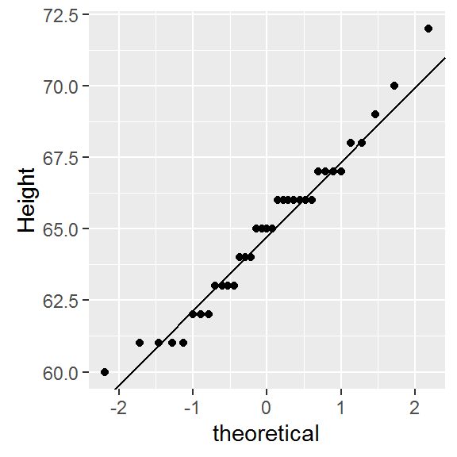

```r
library(ggplot2)

# Find the slope and intercept of the line that passes through the 1st and 3rd
# quartile of the normal q-q plot

y     <- quantile(alto, c(0.25, 0.75)) # Find the 1st and 3rd quartiles
x     <- qnorm( c(0.25, 0.75))         # Find the matching normal values on the x-axis
slope <- diff(y) / diff(x)             # Compute the line slope
int   <- y[1] - slope * x[1]           # Compute the line intercept

# Generate normal q-q plot

ggplot() + aes(sample=alto) + stat_qq(distribution=qnorm) +
           geom_abline(intercept=int, slope=slope) + ylab("Height")
```

We can, of course, make use of `ggplot`’s faceting function to generate trellised plots. For example, the following plot replicates Cleveland’s figure 2.11 (except for the layout which we’ll setup as a single row of plots instead). But first, we will need to compute the slopes for each singer group. We’ll use `dplyr`’s piping operations to create a new dataframe with singer group name, slope and intercept.

```r
library(dplyr)
intsl <- df %>% group_by(voice.part) %>%
       summarize(q25    = quantile(height,0.25),
                 q75    = quantile(height,0.75),
                 norm25 = qnorm( 0.25),
                 norm75 = qnorm( 0.75),
                 slope  = (q25 - q75) / (norm25 - norm75),
                 int    = q25 - slope * norm25) %>%
       select(voice.part,slope, int)
```

The above chunk creates the following table.

| voice.part | slope | int |
| --- | --- | --- |
| Bass 2 | 2.965204 | 72.000 |
| Bass 1 | 2.223903 | 70.500 |
| Tenor 2 | 1.482602 | 70.000 |
| Tenor 1 | 3.706506 | 68.500 |
| Alto 2 | 2.223903 | 65.500 |
| Alto 1 | 2.594554 | 64.750 |
| Soprano 2 | 2.779879 | 63.875 |
| Soprano 1 | 1.667927 | 63.875 |

It’s important that the `voice.part` names match those in `df` letter-for-letter so that when `ggplot` is called, it will know which facet to assign the slope and intercept values to via `geom_abline`.

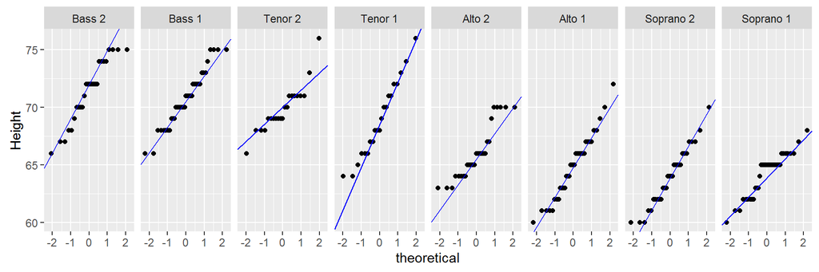

```r
ggplot(df, aes(sample=height)) + stat_qq(distribution=qnorm) +
           geom_abline(data=intsl, aes(intercept=int, slope=slope), col="blue") +
           facet_wrap(~voice.part,nrow=1) + ylab("Height")
```

Manny Gimond (2016)